# Module 6: Feature Engineering for Commodities

## Learning Objectives

By the end of this module, you will:

1. Understand the critical importance of temporal discipline in feature engineering
2. Master the `TemporalFeatureEngineer` class for creating time-aware features
3. Build price-based features: returns, volatility, z-scores, and momentum
4. Create fundamental features from inventory, supply-demand, and cost curves
5. Engineer seasonal and interaction features for commodities
6. Apply feature engineering to crude oil price prediction

## Why Feature Engineering Matters

**"Feature engineering is often the difference between a mediocre model and a great one."**

In commodities trading, your features encode economic theories about what drives prices. Good features:

- Capture market microstructure and fundamentals
- Respect temporal causality (no look-ahead bias)
- Are robust to data revisions and gaps
- Generalize across market regimes

```python
# Standard imports
import numpy as np
import pandas as pd
import matplotlib.pyplot as plt
import seaborn as sns
from datetime import datetime, timedelta
import warnings
warnings.filterwarnings('ignore')

# Set style
plt.style.use('seaborn-v0_8-darkgrid')
sns.set_palette("husl")

# Display settings
pd.set_option('display.max_columns', None)
pd.set_option('display.precision', 4)

print("✓ Environment configured")
```

```
✓ Environment configured
```

```python
# Import fair_value_toolkit
import sys
sys.path.insert(0, '../../src')

from fair_value_toolkit.features import (
    TemporalFeatureEngineer,
    FeatureMetadata,
    create_lagged_features,
    create_rolling_features,
    create_seasonal_features,
    create_commodity_features
)

print("✓ fair_value_toolkit imported")
```

```
✓ fair_value_toolkit imported
```

## Part 1: The Golden Rule - Never Use Future Information

### The Problem with Look-Ahead Bias

Consider this innocent-looking code:

```
# WRONG - This uses future information!
df['price_zscore'] = (df['price'] - df['price'].mean()) / df['price'].std()
```

**Why is this wrong?**

The `.mean()` and `.std()` are calculated using the **entire dataset**, including future observations. When training on January 2020 data, you're using statistics from December 2023!

### The Correct Way: Rolling Statistics

```python
# Create synthetic commodity price data
np.random.seed(42)
dates = pd.date_range('2020-01-01', '2023-12-31', freq='D')
n = len(dates)

# Simulate crude oil prices with trend, seasonality, and noise
trend = np.linspace(50, 70, n)
seasonality = 10 * np.sin(2 * np.pi * np.arange(n) / 365.25)
noise = np.random.normal(0, 5, n)
price = trend + seasonality + noise

# Create DataFrame
df = pd.DataFrame({
    'price': price,
    'inventory': 1000 + np.random.normal(0, 100, n).cumsum(),
    'production': 100 + np.random.normal(0, 5, n),
    'consumption': 98 + np.random.normal(0, 5, n),
}, index=dates)

print(f"Created synthetic commodity data: {len(df)} days")
print(f"Date range: {df.index[0].date()} to {df.index[-1].date()}")
df.head()
```

```
Created synthetic commodity data: 1461 days
Date range: 2020-01-01 to 2023-12-31
```

|  | price | inventory | production | consumption |
| --- | --- | --- | --- | --- |
| 2020-01-01 | 52.4836 | 877.5702 | 99.0265 | 98.9896 |
| 2020-01-02 | 49.4944 | 856.6679 | 99.6791 | 94.9626 |
| 2020-01-03 | 53.6098 | 771.6158 | 100.4588 | 95.9782 |
| 2020-01-04 | 58.1721 | 713.5635 | 101.2612 | 94.5686 |
| 2020-01-05 | 49.5716 | 772.4213 | 99.4189 | 90.8366 |

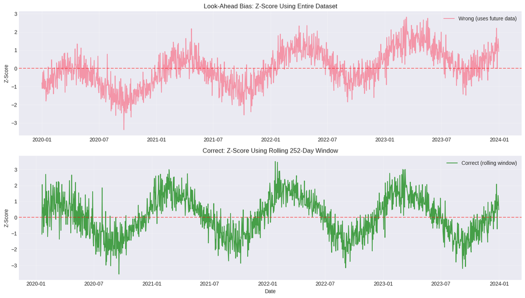

```
Key Difference:
Wrong z-score has mean: 0.0000 (should be ~0 everywhere)
Correct z-score early values are NaN until window fills up
```

```python
# Demonstrate look-ahead bias
# WRONG way (uses future data)
df['zscore_wrong'] = (df['price'] - df['price'].mean()) / df['price'].std()

# CORRECT way (uses only past data)
window = 252  # 1 year
rolling_mean = df['price'].rolling(window=window, min_periods=20).mean()
rolling_std = df['price'].rolling(window=window, min_periods=20).std()
df['zscore_correct'] = (df['price'] - rolling_mean) / rolling_std

# Compare
fig, axes = plt.subplots(2, 1, figsize=(14, 8))

# Plot 1: Wrong z-score
axes[0].plot(df.index, df['zscore_wrong'], label='Wrong (uses future data)', alpha=0.7)
axes[0].axhline(0, color='red', linestyle='--', alpha=0.5)
axes[0].set_ylabel('Z-Score')
axes[0].set_title('Look-Ahead Bias: Z-Score Using Entire Dataset')
axes[0].legend()
axes[0].grid(True, alpha=0.3)

# Plot 2: Correct z-score
axes[1].plot(df.index, df['zscore_correct'], label='Correct (rolling window)', color='green', alpha=0.7)
axes[1].axhline(0, color='red', linestyle='--', alpha=0.5)
axes[1].set_ylabel('Z-Score')
axes[1].set_xlabel('Date')
axes[1].set_title('Correct: Z-Score Using Rolling 252-Day Window')
axes[1].legend()
axes[1].grid(True, alpha=0.3)

plt.tight_layout()
plt.show()

print("\nKey Difference:")
print(f"Wrong z-score has mean: {df['zscore_wrong'].mean():.4f} (should be ~0 everywhere)")
print(f"Correct z-score early values are NaN until window fills up")
```

### Key Insight

Notice how the "correct" z-score:

1. Starts with NaN values (until the window fills)
2. Adapts over time as the rolling window moves
3. Never uses future information

The "wrong" z-score appears more stable because it uses information from the entire time series, creating an illusion of predictability.

## Part 2: The TemporalFeatureEngineer Class

The `TemporalFeatureEngineer` automates temporal feature creation while maintaining strict discipline. It tracks:

- **Feature metadata**: What each feature represents
- **Lookback periods**: How much history is used
- **Transformation logic**: How to apply features consistently

### Basic Usage Pattern

```python
# Initialize the feature engineer
engineer = TemporalFeatureEngineer(
    target_column='price',
    fill_method='ffill'  # Forward fill missing values
)

# Fit on training data (stores statistics)
train_end = '2022-12-31'
train_data = df.loc[:train_end].copy()

engineer.fit(train_data)

print("✓ TemporalFeatureEngineer fitted")
print(f"  Training samples: {len(train_data)}")
print(f"  Features in training: {list(train_data.columns)}")
```

```
✓ TemporalFeatureEngineer fitted
  Training samples: 1096
  Features in training: ['price', 'inventory', 'production', 'consumption', 'zscore_wrong', 'zscore_correct']
```

## Part 3: Price-Based Features

Price-based features capture market dynamics:

- **Returns**: Price changes over various horizons
- **Volatility**: Risk and uncertainty measures
- **Z-scores**: Relative price levels
- **Momentum**: Trending behavior

### 3.1 Returns at Multiple Horizons

```python
# Add return features
features_df = train_data.copy()

# Returns over different periods
periods = [1, 5, 21, 63]  # 1d, 1w, 1m, 3m
features_df = engineer.add_returns(
    features_df,
    columns=['price'],
    periods=periods,
    log_return=False
)

print("✓ Return features added")
print(f"\nNew columns: {[c for c in features_df.columns if 'return' in c]}")
print(f"\nSample values:")
features_df[['price'] + [c for c in features_df.columns if 'return' in c]].tail()
```

```
✓ Return features added

New columns: ['price_return1', 'price_return5', 'price_return21', 'price_return63']

Sample values:
```

|  | price | price_return1 | price_return5 | price_return21 | price_return63 |
| --- | --- | --- | --- | --- | --- |
| 2022-12-27 | 63.9429 | 0.0056 | -0.0646 | 0.0633 | 0.1032 |
| 2022-12-28 | 67.9524 | 0.0627 | 0.0521 | 0.0799 | 0.3628 |
| 2022-12-29 | 64.7594 | -0.0470 | 0.0398 | 0.0600 | 0.2043 |
| 2022-12-30 | 68.3485 | 0.0554 | 0.0887 | 0.2548 | 0.4602 |
| 2022-12-31 | 64.4674 | -0.0568 | 0.0139 | -0.0238 | 0.1263 |

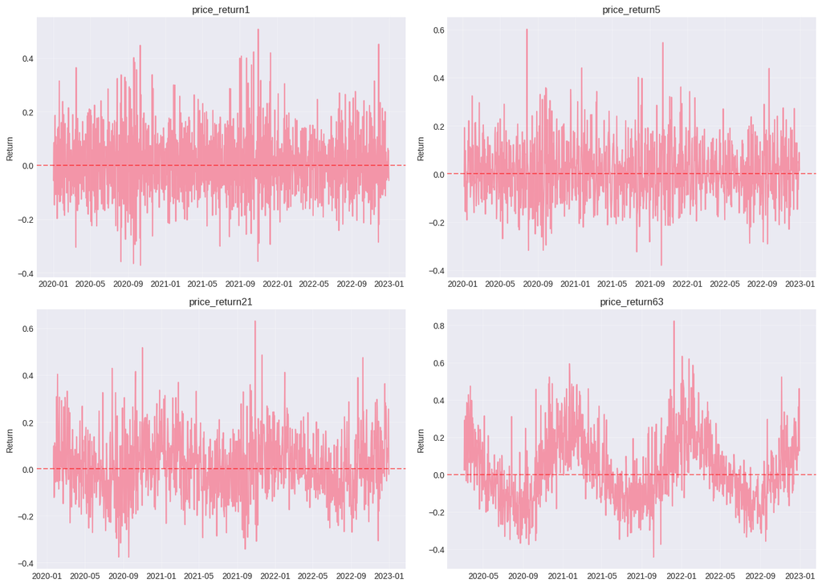

```
Return Correlations:
                price_return1  price_return5  price_return21  price_return63
price_return1          1.0000         0.4603          0.4408          0.3680
price_return5          0.4603         1.0000          0.4923          0.3996
price_return21         0.4408         0.4923          1.0000          0.5424
price_return63         0.3680         0.3996          0.5424          1.0000
```

```python
# Visualize returns
fig, axes = plt.subplots(2, 2, figsize=(14, 10))
axes = axes.ravel()

return_cols = [c for c in features_df.columns if 'return' in c]
for idx, col in enumerate(return_cols[:4]):
    axes[idx].plot(features_df.index, features_df[col], alpha=0.7)
    axes[idx].axhline(0, color='red', linestyle='--', alpha=0.5)
    axes[idx].set_title(col)
    axes[idx].set_ylabel('Return')
    axes[idx].grid(True, alpha=0.3)

plt.tight_layout()
plt.show()

# Calculate correlations
corr_matrix = features_df[return_cols].corr()
print("\nReturn Correlations:")
print(corr_matrix)
```

### 3.2 Volatility Measures

Volatility captures uncertainty and risk. High volatility periods often precede mean reversion or regime changes.

```
✓ Volatility features added
Volatility columns: ['price_vol5', 'price_vol21', 'price_vol63']
```

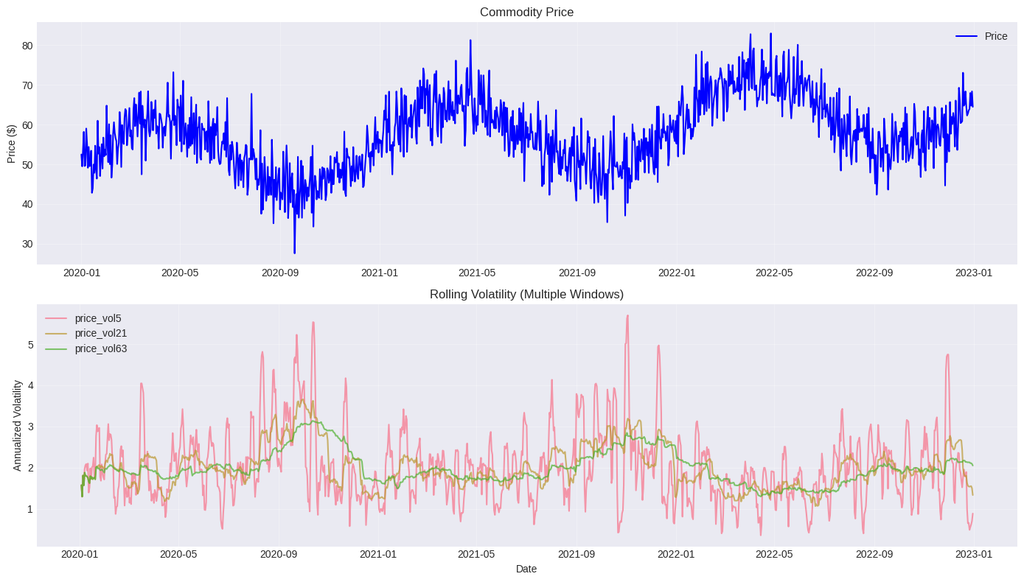

```python
# Add volatility features
vol_windows = [5, 21, 63]  # 1w, 1m, 3m
features_df = engineer.add_volatility(
    features_df,
    columns=['price'],
    windows=vol_windows,
    method='std'
)

print("✓ Volatility features added")
vol_cols = [c for c in features_df.columns if 'vol' in c]
print(f"Volatility columns: {vol_cols}")

# Plot
fig, axes = plt.subplots(2, 1, figsize=(14, 8))

# Price
axes[0].plot(features_df.index, features_df['price'], label='Price', color='blue')
axes[0].set_ylabel('Price ($)')
axes[0].set_title('Commodity Price')
axes[0].legend()
axes[0].grid(True, alpha=0.3)

# Volatility
for col in vol_cols:
    axes[1].plot(features_df.index, features_df[col], label=col, alpha=0.7)
axes[1].set_ylabel('Annualized Volatility')
axes[1].set_xlabel('Date')
axes[1].set_title('Rolling Volatility (Multiple Windows)')
axes[1].legend()
axes[1].grid(True, alpha=0.3)

plt.tight_layout()
plt.show()
```

### 3.3 Z-Scores and Momentum

Z-scores measure how far price has deviated from its historical mean, normalized by volatility. This is crucial for mean reversion strategies.

```
✓ Z-score features added
Z-score columns: ['zscore_wrong', 'zscore_correct', 'price_zscore21', 'price_zscore63', 'price_zscore252']
```

[output not shown]

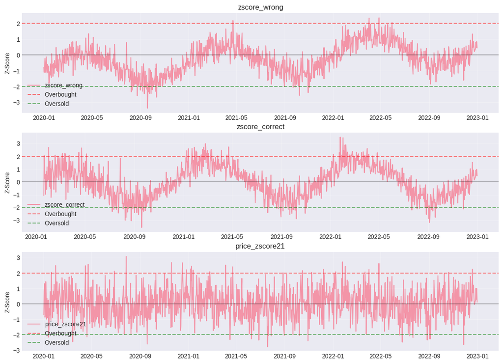

```python
# Add z-score features
zscore_windows = [21, 63, 252]  # 1m, 3m, 1y
features_df = engineer.add_zscore(
    features_df,
    columns=['price'],
    windows=zscore_windows
)

print("✓ Z-score features added")
zscore_cols = [c for c in features_df.columns if 'zscore' in c]
print(f"Z-score columns: {zscore_cols}")

# Plot z-scores
fig, axes = plt.subplots(3, 1, figsize=(14, 10))

for idx, col in enumerate(zscore_cols):
    axes[idx].plot(features_df.index, features_df[col], label=col, alpha=0.7)
    axes[idx].axhline(0, color='black', linestyle='-', alpha=0.3)
    axes[idx].axhline(2, color='red', linestyle='--', alpha=0.5, label='Overbought')
    axes[idx].axhline(-2, color='green', linestyle='--', alpha=0.5, label='Oversold')
    axes[idx].set_ylabel('Z-Score')
    axes[idx].set_title(col)
    axes[idx].legend()
    axes[idx].grid(True, alpha=0.3)

axes[-1].set_xlabel('Date')
plt.tight_layout()
plt.show()

# Statistics
print("\nZ-Score Statistics:")
print(features_df[zscore_cols].describe())
```

```python
# Add rolling statistics for momentum
features_df = engineer.add_rolling_stats(
    features_df,
    columns=['price'],
    windows=[5, 21],
    stats=['mean', 'min', 'max']
)

print("✓ Rolling statistics added")
roll_cols = [c for c in features_df.columns if 'roll' in c]
print(f"Rolling stat columns: {roll_cols}")
```

```
✓ Rolling statistics added
Rolling stat columns: ['price_roll5_mean', 'price_roll5_min', 'price_roll5_max', 'price_roll21_mean', 'price_roll21_min', 'price_roll21_max']
```

## Part 4: Fundamental Features

Fundamental features encode economic theories about what drives commodity prices:

- **Inventory levels**: Storage theory (Working, Kaldor)
- **Supply-demand balance**: Market clearing
- **Cost curves**: Marginal cost of production

### 4.1 Inventory Features

```python
# Add inventory features
# 1. Lagged inventory (storage levels)
features_df = engineer.add_lags(
    features_df,
    columns=['inventory'],
    lags=[1, 5, 10]
)

# 2. Inventory z-scores (deviation from normal)
features_df = engineer.add_zscore(
    features_df,
    columns=['inventory'],
    windows=[12, 52]  # ~2 weeks, ~2 months (assuming weekly data)
)

# 3. Rolling inventory statistics
features_df = engineer.add_rolling_stats(
    features_df,
    columns=['inventory'],
    windows=[4, 12],
    stats=['mean', 'std']
)

# 4. Inventory changes
features_df['inventory_change'] = features_df['inventory'].diff()
features_df['inventory_change_pct'] = features_df['inventory'].pct_change()

print("✓ Inventory features created")
inventory_cols = [c for c in features_df.columns if 'inventory' in c]
print(f"\nInventory features ({len(inventory_cols)}):")
for col in inventory_cols[:10]:  # Show first 10
    print(f"  - {col}")
```

```
✓ Inventory features created

Inventory features (12):
  - inventory
  - inventory_lag1
  - inventory_lag5
  - inventory_lag10
  - inventory_zscore12
  - inventory_zscore52
  - inventory_roll4_mean
  - inventory_roll4_std
  - inventory_roll12_mean
  - inventory_roll12_std
```

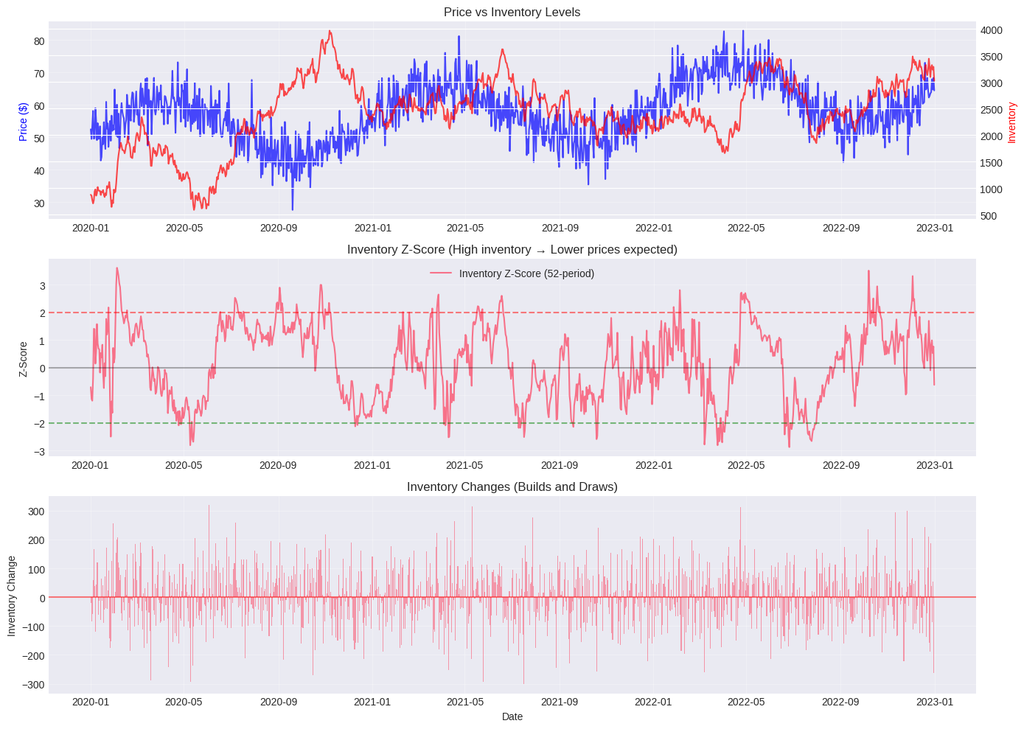

```
Inventory-Price Correlation Analysis:
Price vs Inventory: -0.012
Price vs Inventory Change: -0.009
Price vs Inventory Z-Score: -0.088
```

```python
# Visualize inventory-price relationship
fig, axes = plt.subplots(3, 1, figsize=(14, 10))

# Price and inventory levels
ax1 = axes[0]
ax2 = ax1.twinx()
ax1.plot(features_df.index, features_df['price'], 'b-', label='Price', alpha=0.7)
ax2.plot(features_df.index, features_df['inventory'], 'r-', label='Inventory', alpha=0.7)
ax1.set_ylabel('Price ($)', color='b')
ax2.set_ylabel('Inventory', color='r')
ax1.set_title('Price vs Inventory Levels')
ax1.grid(True, alpha=0.3)

# Inventory z-score
axes[1].plot(features_df.index, features_df['inventory_zscore52'], label='Inventory Z-Score (52-period)')
axes[1].axhline(0, color='black', linestyle='-', alpha=0.3)
axes[1].axhline(2, color='red', linestyle='--', alpha=0.5)
axes[1].axhline(-2, color='green', linestyle='--', alpha=0.5)
axes[1].set_ylabel('Z-Score')
axes[1].set_title('Inventory Z-Score (High inventory → Lower prices expected)')
axes[1].legend()
axes[1].grid(True, alpha=0.3)

# Inventory changes
axes[2].bar(features_df.index, features_df['inventory_change'], alpha=0.7, width=1)
axes[2].axhline(0, color='red', linestyle='-', alpha=0.5)
axes[2].set_ylabel('Inventory Change')
axes[2].set_xlabel('Date')
axes[2].set_title('Inventory Changes (Builds and Draws)')
axes[2].grid(True, alpha=0.3)

plt.tight_layout()
plt.show()

# Correlation analysis
print("\nInventory-Price Correlation Analysis:")
print(f"Price vs Inventory: {features_df['price'].corr(features_df['inventory']):.3f}")
print(f"Price vs Inventory Change: {features_df['price'].corr(features_df['inventory_change']):.3f}")
print(f"Price vs Inventory Z-Score: {features_df['price'].corr(features_df['inventory_zscore52']):.3f}")
```

### 4.2 Supply-Demand Balance Features

The fundamental equation: **Price = f(Demand - Supply)**

When demand exceeds supply, prices rise. When supply exceeds demand, prices fall.

```
✓ Supply-demand features created
```

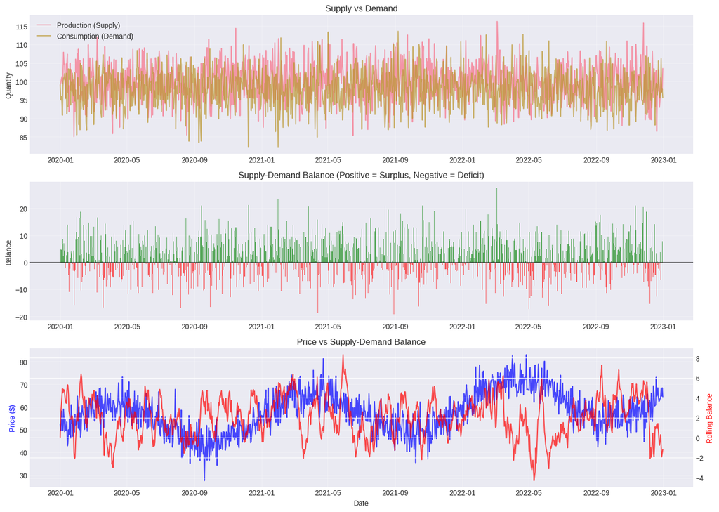

```
Supply-Demand Correlation:
Price vs Balance: -0.014
Price vs Rolling Balance: -0.056
```

```python
# Create supply-demand balance features
# 1. Raw balance
features_df['supply_demand_balance'] = features_df['production'] - features_df['consumption']

# 2. Rolling balance statistics
features_df = engineer.add_rolling_stats(
    features_df,
    columns=['supply_demand_balance'],
    windows=[4, 12],
    stats=['mean', 'sum']
)

# 3. Cumulative balance (proxy for inventory change)
features_df['cumulative_balance'] = features_df['supply_demand_balance'].cumsum()

# 4. Balance z-score
features_df = engineer.add_zscore(
    features_df,
    columns=['supply_demand_balance'],
    windows=[52]
)

print("✓ Supply-demand features created")

# Visualize
fig, axes = plt.subplots(3, 1, figsize=(14, 10))

# Supply vs Demand
axes[0].plot(features_df.index, features_df['production'], label='Production (Supply)', alpha=0.7)
axes[0].plot(features_df.index, features_df['consumption'], label='Consumption (Demand)', alpha=0.7)
axes[0].set_ylabel('Quantity')
axes[0].set_title('Supply vs Demand')
axes[0].legend()
axes[0].grid(True, alpha=0.3)

# Balance
axes[1].bar(features_df.index, features_df['supply_demand_balance'],
           color=['red' if x < 0 else 'green' for x in features_df['supply_demand_balance']],
           alpha=0.6, width=1)
axes[1].axhline(0, color='black', linestyle='-', alpha=0.5)
axes[1].set_ylabel('Balance')
axes[1].set_title('Supply-Demand Balance (Positive = Surplus, Negative = Deficit)')
axes[1].grid(True, alpha=0.3)

# Price overlay
ax_price = axes[2]
ax_balance = ax_price.twinx()
ax_price.plot(features_df.index, features_df['price'], 'b-', label='Price', alpha=0.7)
ax_balance.plot(features_df.index, features_df['supply_demand_balance_roll12_mean'],
               'r-', label='12-Period Rolling Balance', alpha=0.7)
ax_price.set_ylabel('Price ($)', color='b')
ax_balance.set_ylabel('Rolling Balance', color='r')
ax_price.set_xlabel('Date')
ax_price.set_title('Price vs Supply-Demand Balance')
ax_price.grid(True, alpha=0.3)

plt.tight_layout()
plt.show()

print("\nSupply-Demand Correlation:")
print(f"Price vs Balance: {features_df['price'].corr(features_df['supply_demand_balance']):.3f}")
print(f"Price vs Rolling Balance: {features_df['price'].corr(features_df['supply_demand_balance_roll12_mean']):.3f}")
```

### 4.3 Cost Curve Features

In competitive markets, price gravitates toward the marginal cost of production. We can proxy this with:

- Input costs (energy, labor)
- Exchange rates
- Technology indices

```
✓ Cost curve features created
```

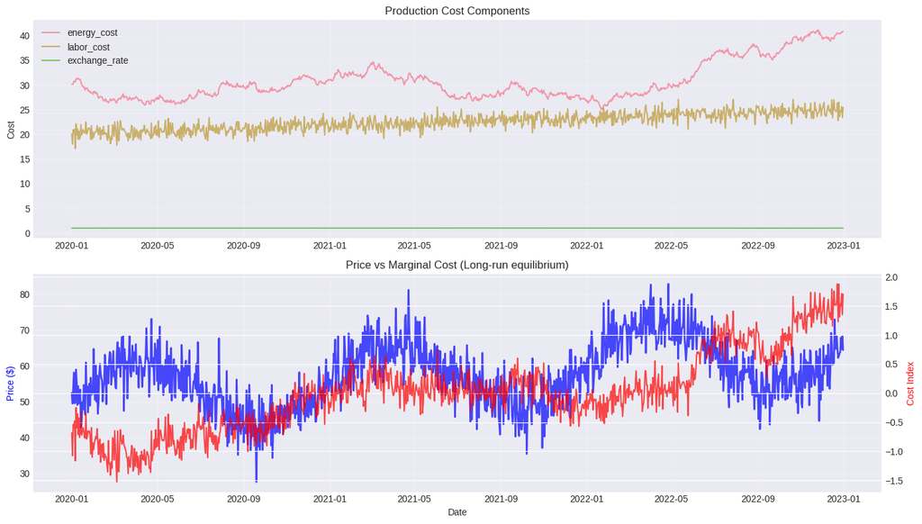

```
Cost-Price Correlation:
Price vs Marginal Cost Index: 0.202
```

```python
# Simulate cost curve proxies
np.random.seed(42)
features_df['energy_cost'] = 30 + np.random.normal(0, 3, len(features_df)).cumsum() * 0.1
features_df['labor_cost'] = 20 + np.linspace(0, 5, len(features_df)) + np.random.normal(0, 1, len(features_df))
features_df['exchange_rate'] = 1.0 + np.random.normal(0, 0.05, len(features_df)).cumsum() * 0.01

# Create composite marginal cost
# Simple weighted average of normalized costs
from sklearn.preprocessing import StandardScaler

cost_components = ['energy_cost', 'labor_cost', 'exchange_rate']
scaler = StandardScaler()
scaled_costs = scaler.fit_transform(features_df[cost_components])

# Weighted marginal cost (energy has higher weight)
weights = np.array([0.5, 0.3, 0.2])
features_df['marginal_cost_index'] = scaled_costs @ weights

# Add rolling cost features
features_df = engineer.add_rolling_stats(
    features_df,
    columns=['marginal_cost_index'],
    windows=[21],
    stats=['mean', 'std']
)

print("✓ Cost curve features created")

# Visualize
fig, axes = plt.subplots(2, 1, figsize=(14, 8))

# Cost components
for comp in cost_components:
    axes[0].plot(features_df.index, features_df[comp], label=comp, alpha=0.7)
axes[0].set_ylabel('Cost')
axes[0].set_title('Production Cost Components')
axes[0].legend()
axes[0].grid(True, alpha=0.3)

# Price vs marginal cost
ax1 = axes[1]
ax2 = ax1.twinx()
ax1.plot(features_df.index, features_df['price'], 'b-', label='Price', alpha=0.7, linewidth=2)
ax2.plot(features_df.index, features_df['marginal_cost_index'], 'r-', label='Marginal Cost Index', alpha=0.7)
ax1.set_ylabel('Price ($)', color='b')
ax2.set_ylabel('Cost Index', color='r')
ax1.set_xlabel('Date')
ax1.set_title('Price vs Marginal Cost (Long-run equilibrium)')
ax1.grid(True, alpha=0.3)

plt.tight_layout()
plt.show()

print("\nCost-Price Correlation:")
print(f"Price vs Marginal Cost Index: {features_df['price'].corr(features_df['marginal_cost_index']):.3f}")
```

## Part 5: Seasonal and Interaction Features

### 5.1 Calendar Effects

Commodities exhibit seasonal patterns due to:

- Weather (heating oil in winter, cooling demand in summer)
- Crop cycles (agricultural commodities)
- Industrial production patterns
- Holiday effects

```
✓ Seasonal features added

Seasonal columns: ['month', 'quarter', 'dayofweek', 'is_month_end', 'is_quarter_end']
```

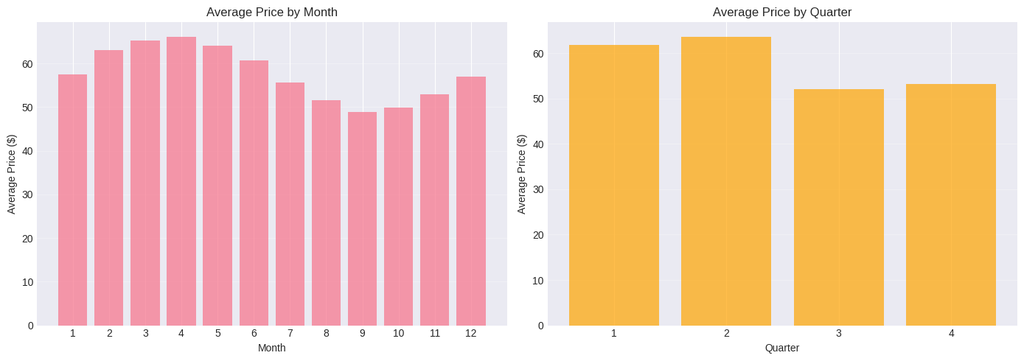

```
ANOVA Test for Monthly Seasonality:
F-statistic: 78.01
P-value: 0.0000
✓ Statistically significant seasonal pattern detected
```

```python
# Add seasonal features
features_df = engineer.add_seasonal(
    features_df,
    include=['month', 'quarter', 'dayofweek', 'is_month_end', 'is_quarter_end']
)

print("✓ Seasonal features added")
seasonal_cols = ['month', 'quarter', 'dayofweek', 'is_month_end', 'is_quarter_end']
print(f"\nSeasonal columns: {seasonal_cols}")

# Analyze seasonality
monthly_avg = features_df.groupby('month')['price'].mean()
quarterly_avg = features_df.groupby('quarter')['price'].mean()

fig, axes = plt.subplots(1, 2, figsize=(14, 5))

# Monthly seasonality
axes[0].bar(monthly_avg.index, monthly_avg.values, alpha=0.7)
axes[0].set_xlabel('Month')
axes[0].set_ylabel('Average Price ($)')
axes[0].set_title('Average Price by Month')
axes[0].set_xticks(range(1, 13))
axes[0].grid(True, alpha=0.3, axis='y')

# Quarterly seasonality
axes[1].bar(quarterly_avg.index, quarterly_avg.values, alpha=0.7, color='orange')
axes[1].set_xlabel('Quarter')
axes[1].set_ylabel('Average Price ($)')
axes[1].set_title('Average Price by Quarter')
axes[1].set_xticks(range(1, 5))
axes[1].grid(True, alpha=0.3, axis='y')

plt.tight_layout()
plt.show()

# Statistical test for seasonality
from scipy.stats import f_oneway

monthly_groups = [features_df[features_df['month'] == m]['price'].dropna() for m in range(1, 13)]
f_stat, p_value = f_oneway(*monthly_groups)

print(f"\nANOVA Test for Monthly Seasonality:")
print(f"F-statistic: {f_stat:.2f}")
print(f"P-value: {p_value:.4f}")
if p_value < 0.05:
    print("✓ Statistically significant seasonal pattern detected")
else:
    print("✗ No significant seasonal pattern")
```

### 5.2 Cross-Commodity Spreads

Commodities don't trade in isolation. Related commodities can provide signals:

- Crude oil vs refined products (crack spread)
- Corn vs ethanol
- Natural gas vs power

```
✓ Cross-commodity spread features created
```

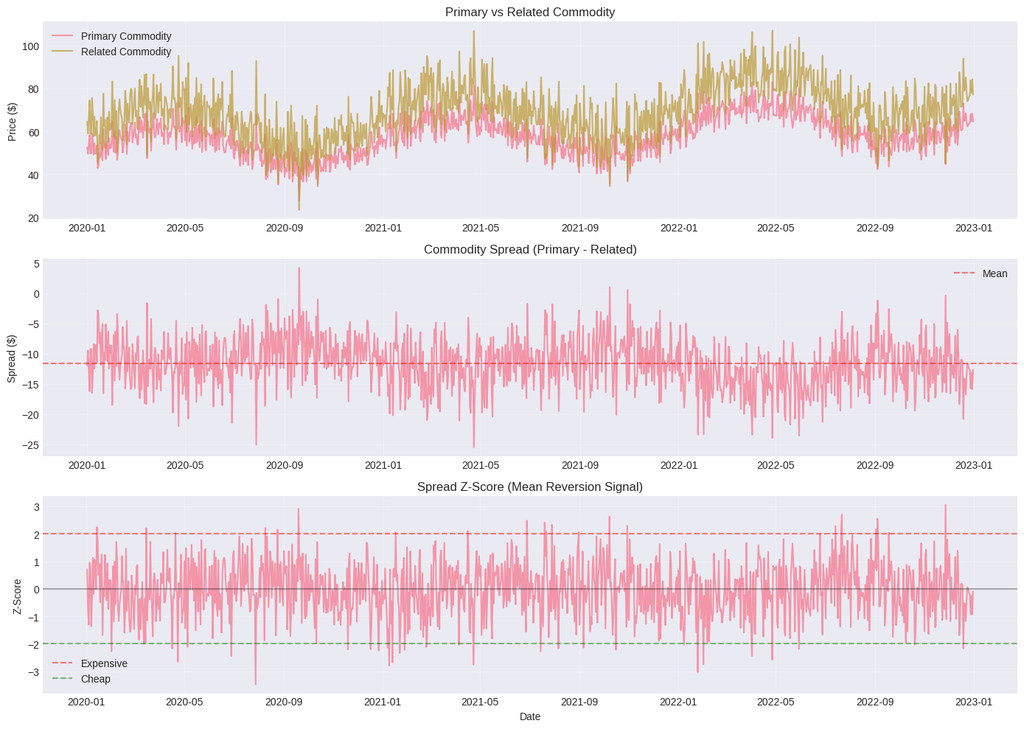

```
Spread Statistics:
Mean spread: $-11.63
Spread volatility: $4.19
Spread correlation with price: -0.817
```

```python
# Simulate related commodity
np.random.seed(42)
features_df['related_commodity'] = features_df['price'] * 1.2 + np.random.normal(0, 3, len(features_df))

# Create spread features
features_df['commodity_spread'] = features_df['price'] - features_df['related_commodity']
features_df['commodity_ratio'] = features_df['price'] / features_df['related_commodity']

# Rolling spread statistics
features_df = engineer.add_rolling_stats(
    features_df,
    columns=['commodity_spread'],
    windows=[21],
    stats=['mean', 'std']
)

# Spread z-score
features_df = engineer.add_zscore(
    features_df,
    columns=['commodity_spread'],
    windows=[63]
)

print("✓ Cross-commodity spread features created")

# Visualize
fig, axes = plt.subplots(3, 1, figsize=(14, 10))

# Prices
axes[0].plot(features_df.index, features_df['price'], label='Primary Commodity', alpha=0.7)
axes[0].plot(features_df.index, features_df['related_commodity'], label='Related Commodity', alpha=0.7)
axes[0].set_ylabel('Price ($)')
axes[0].set_title('Primary vs Related Commodity')
axes[0].legend()
axes[0].grid(True, alpha=0.3)

# Spread
axes[1].plot(features_df.index, features_df['commodity_spread'], alpha=0.7)
axes[1].axhline(features_df['commodity_spread'].mean(), color='red', linestyle='--', alpha=0.5, label='Mean')
axes[1].set_ylabel('Spread ($)')
axes[1].set_title('Commodity Spread (Primary - Related)')
axes[1].legend()
axes[1].grid(True, alpha=0.3)

# Spread z-score
axes[2].plot(features_df.index, features_df['commodity_spread_zscore63'], alpha=0.7)
axes[2].axhline(0, color='black', linestyle='-', alpha=0.3)
axes[2].axhline(2, color='red', linestyle='--', alpha=0.5, label='Expensive')
axes[2].axhline(-2, color='green', linestyle='--', alpha=0.5, label='Cheap')
axes[2].set_ylabel('Z-Score')
axes[2].set_xlabel('Date')
axes[2].set_title('Spread Z-Score (Mean Reversion Signal)')
axes[2].legend()
axes[2].grid(True, alpha=0.3)

plt.tight_layout()
plt.show()

print("\nSpread Statistics:")
print(f"Mean spread: ${features_df['commodity_spread'].mean():.2f}")
print(f"Spread volatility: ${features_df['commodity_spread'].std():.2f}")
print(f"Spread correlation with price: {features_df['price'].corr(features_df['commodity_spread']):.3f}")
```

### 5.3 Interaction Features

Sometimes the combination of features is more predictive than individual features:

- High inventory + low demand = very bearish
- Low inventory + high volatility = explosive upside

```python
# Create interaction features
interactions = [
    ('inventory_zscore52', 'supply_demand_balance'),
    ('price_vol21', 'inventory_zscore52'),
]

features_df = engineer.add_interactions(
    features_df,
    interactions=interactions,
    operation='multiply'
)

print("✓ Interaction features created")
interaction_cols = [c for c in features_df.columns if '_x_' in c]
print(f"Interaction features: {interaction_cols}")

# Analyze predictive power
print("\nInteraction Feature Correlations with Price:")
for col in interaction_cols:
    corr = features_df['price'].corr(features_df[col])
    print(f"{col}: {corr:.3f}")
```

```
✓ Interaction features created
Interaction features: ['inventory_zscore52_x_supply_demand_balance', 'price_vol21_x_inventory_zscore52']

Interaction Feature Correlations with Price:
inventory_zscore52_x_supply_demand_balance: -0.026
price_vol21_x_inventory_zscore52: -0.138
```

### 5.4 Relative Strength

Relative strength measures how one commodity performs versus a benchmark.

```
✓ Relative strength features added
Relative strength columns: ['price_rs_related_commodity_21', 'price_rs_related_commodity_63']
```

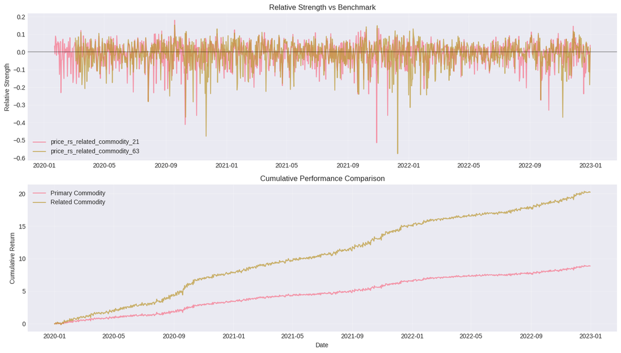

```python
# Add relative strength features
features_df = engineer.add_relative_strength(
    features_df,
    column='price',
    benchmark_column='related_commodity',
    windows=[21, 63]
)

print("✓ Relative strength features added")
rs_cols = [c for c in features_df.columns if '_rs_' in c]
print(f"Relative strength columns: {rs_cols}")

# Plot
fig, axes = plt.subplots(2, 1, figsize=(14, 8))

# Relative strength
for col in rs_cols:
    axes[0].plot(features_df.index, features_df[col], label=col, alpha=0.7)
axes[0].axhline(0, color='black', linestyle='-', alpha=0.3)
axes[0].set_ylabel('Relative Strength')
axes[0].set_title('Relative Strength vs Benchmark')
axes[0].legend()
axes[0].grid(True, alpha=0.3)

# Cumulative relative performance
price_ret = features_df['price'].pct_change().fillna(0).cumsum()
bench_ret = features_df['related_commodity'].pct_change().fillna(0).cumsum()
axes[1].plot(features_df.index, price_ret, label='Primary Commodity', alpha=0.7)
axes[1].plot(features_df.index, bench_ret, label='Related Commodity', alpha=0.7)
axes[1].set_ylabel('Cumulative Return')
axes[1].set_xlabel('Date')
axes[1].set_title('Cumulative Performance Comparison')
axes[1].legend()
axes[1].grid(True, alpha=0.3)

plt.tight_layout()
plt.show()
```

## Part 6: Feature Metadata and Inspection

The `TemporalFeatureEngineer` tracks metadata for all created features. This is crucial for:

- Understanding feature lineage
- Identifying maximum lookback period
- Documenting model inputs

```python
# Get feature metadata
feature_info = engineer.get_feature_info()

print(f"Total registered features: {len(feature_info)}")
print(f"\nFeature metadata sample:")
print(feature_info.head(15))
```

```
Total registered features: 44

Feature metadata sample:
                 name source        type  lookback  \
0       price_return1  price      return         1
1       price_return5  price      return         5
2      price_return21  price      return        21
3      price_return63  price      return        63
4          price_vol5  price  volatility         5
5         price_vol21  price  volatility        21
6         price_vol63  price  volatility        63
7      price_zscore21  price      zscore        21
8      price_zscore63  price      zscore        63
9     price_zscore252  price      zscore       252
10   price_roll5_mean  price     rolling         5
```

[output cut: 21 more lines]

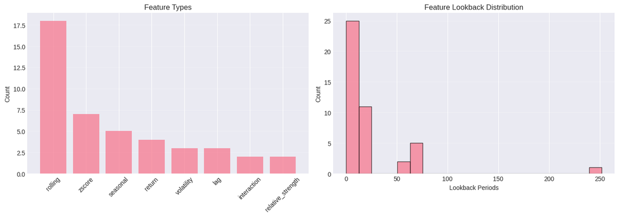

```
Feature Type Distribution:
type
rolling              18
zscore                7
seasonal              5
return                4
volatility            3
lag                   3
interaction           2
relative_strength     2
Name: count, dtype: int64

Maximum lookback period: 252 periods
```

```python
# Analyze feature types
feature_type_counts = feature_info['type'].value_counts()

fig, axes = plt.subplots(1, 2, figsize=(14, 5))

# Feature type distribution
axes[0].bar(feature_type_counts.index, feature_type_counts.values, alpha=0.7)
axes[0].set_ylabel('Count')
axes[0].set_title('Feature Types')
axes[0].tick_params(axis='x', rotation=45)
axes[0].grid(True, alpha=0.3, axis='y')

# Lookback period distribution
axes[1].hist(feature_info['lookback'], bins=20, alpha=0.7, edgecolor='black')
axes[1].set_xlabel('Lookback Periods')
axes[1].set_ylabel('Count')
axes[1].set_title('Feature Lookback Distribution')
axes[1].grid(True, alpha=0.3, axis='y')

plt.tight_layout()
plt.show()

print(f"\nFeature Type Distribution:")
print(feature_type_counts)
print(f"\nMaximum lookback period: {engineer.get_max_lookback()} periods")
```

## Part 7: The Complete Feature Set

Let's create a comprehensive feature set using the convenience function `create_commodity_features()`.

```python
# Start fresh with original data
commodity_data = df.loc[:train_end].copy()

# Use the convenience function
full_features = create_commodity_features(
    commodity_data,
    price_column='price',
    inventory_column='inventory',
    production_column='production',
    consumption_column='consumption'
)

print(f"✓ Complete feature set created")
print(f"\nOriginal columns: {len(commodity_data.columns)}")
print(f"Feature-engineered columns: {len(full_features.columns)}")
print(f"New features added: {len(full_features.columns) - len(commodity_data.columns)}")

print(f"\nFeature columns:")
for i, col in enumerate(full_features.columns, 1):
    print(f"{i:3d}. {col}")
```

```
✓ Complete feature set created

Original columns: 6
Feature-engineered columns: 42
New features added: 36

Feature columns:
  1. price
  2. inventory
  3. production
  4. consumption
  5. zscore_wrong
  6. zscore_correct
  7. price_return1
  8. price_return5
  9. price_return21
 10. price_return63
 11. price_vol5
 12. price_vol21
 13. price_vol63
 14. price_zscore21
 15. price_zscore63
 16. price_zscore252
 17. price_roll5_mean
 18. price_roll5_std
 19. price_roll5_min
 20. price_roll5_max
 21. price_roll21_mean
 22. price_roll21_std
 23. price_roll21_min
 24. price_roll21_max
 25. inventory_lag1
 26. inventory_lag5
 27. inventory_lag10
 28. inventory_roll4_mean
 29. inventory_roll4_std
 30. inventory_roll12_mean
 31. inventory_roll12_std
 32. inventory_zscore12
 33. inventory_zscore52
 34. inventory_change
 35. inventory_change_pct
 36. supply_demand_balance
 37. supply_demand_balance_roll4_mean
 38. supply_demand_balance_roll4_sum
 39. supply_demand_balance_roll12_mean
 40. supply_demand_balance_roll12_sum
 41. month
 42. quarter
```

```
Features with missing values:
price_return63     5.7482
price_return21     1.9161
zscore_correct     1.7336
inventory_lag10    0.9124
inventory_lag5     0.4562
price_return5      0.4562
price_vol5         0.1825
price_vol63        0.1825
price_vol21        0.1825
price_return1      0.0912
dtype: float64
```

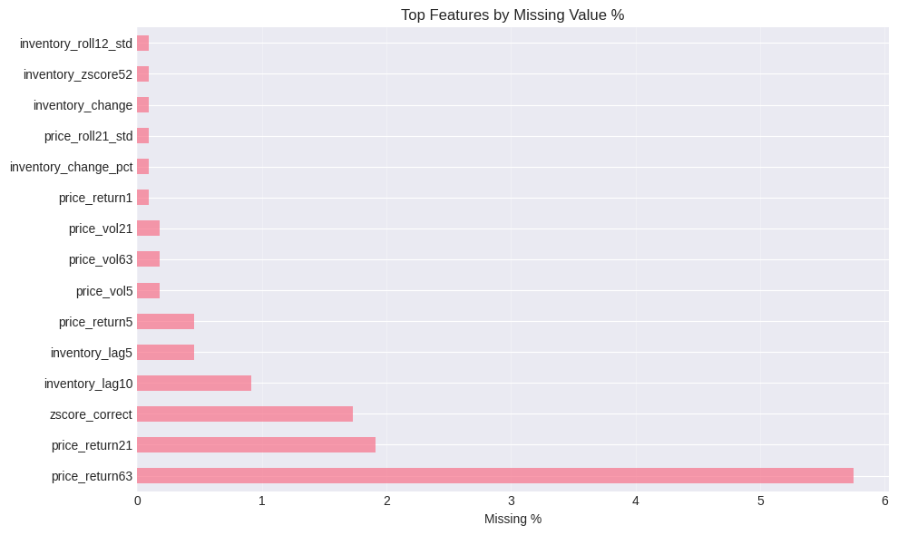

```python
# Check for missing values
missing_pct = (full_features.isnull().sum() / len(full_features) * 100).sort_values(ascending=False)
missing_pct = missing_pct[missing_pct > 0]

if len(missing_pct) > 0:
    print("Features with missing values:")
    print(missing_pct.head(10))

    fig, ax = plt.subplots(figsize=(10, 6))
    missing_pct.head(15).plot(kind='barh', ax=ax, alpha=0.7)
    ax.set_xlabel('Missing %')
    ax.set_title('Top Features by Missing Value %')
    ax.grid(True, alpha=0.3, axis='x')
    plt.tight_layout()
    plt.show()
else:
    print("✓ No missing values in feature set")
```

## Part 8: Feature Correlation Analysis

High correlations between features (multicollinearity) can cause:

- Unstable coefficient estimates
- Poor out-of-sample performance
- Difficulty interpreting feature importance

```
Highly correlated feature pairs (|r| > 0.95):
  price ↔ zscore_wrong: 1.000
  inventory ↔ inventory_lag1: 0.987
  inventory ↔ inventory_roll4_mean: 0.989
  inventory ↔ inventory_roll12_mean: 0.962
  zscore_correct ↔ price_zscore252: 1.000
  price_roll5_mean ↔ price_roll5_min: 0.960
  price_roll5_mean ↔ price_roll5_max: 0.952
  price_roll5_mean ↔ price_roll21_mean: 0.963
  price_roll21_mean ↔ price_roll21_min: 0.964
  inventory_lag1 ↔ inventory_lag5: 0.953
```

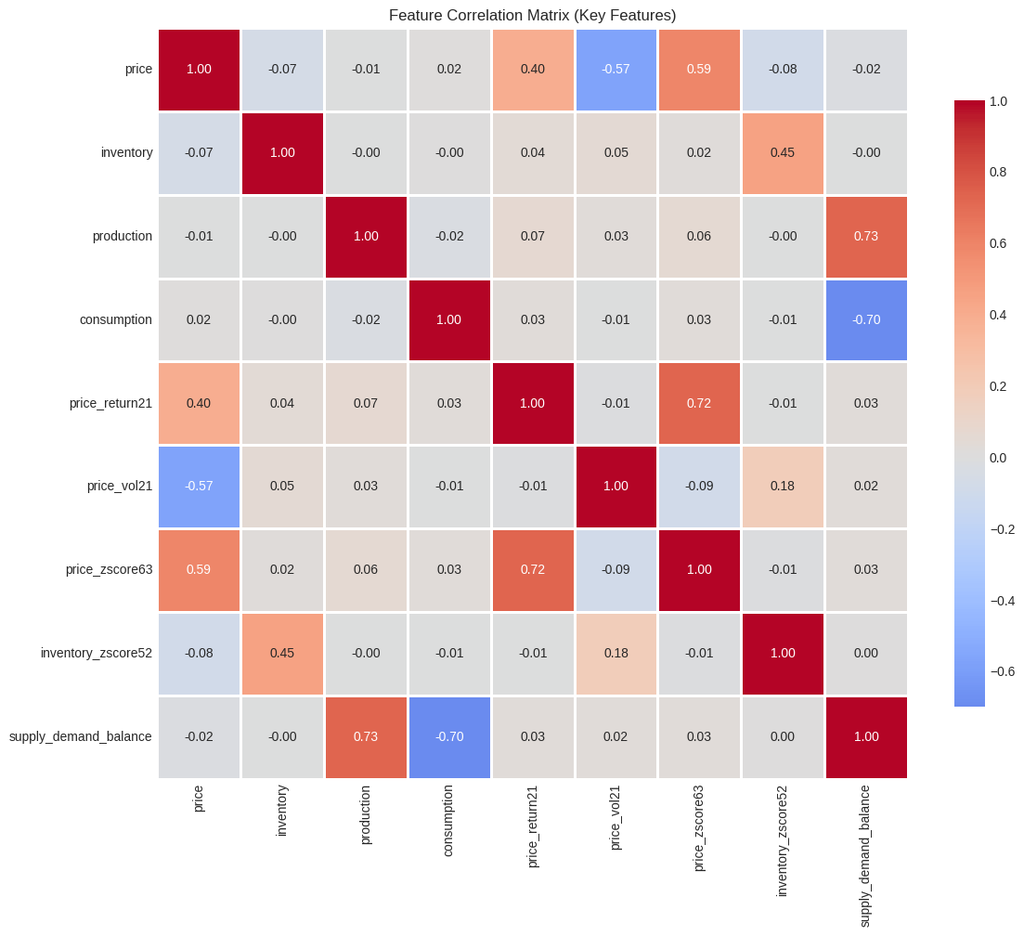

```python
# Select numeric features for correlation analysis
numeric_features = full_features.select_dtypes(include=[np.number]).dropna()

# Calculate correlation matrix
corr_matrix = numeric_features.corr()

# Find highly correlated pairs
high_corr_pairs = []
for i in range(len(corr_matrix.columns)):
    for j in range(i+1, len(corr_matrix.columns)):
        if abs(corr_matrix.iloc[i, j]) > 0.95:
            high_corr_pairs.append((
                corr_matrix.columns[i],
                corr_matrix.columns[j],
                corr_matrix.iloc[i, j]
            ))

print(f"Highly correlated feature pairs (|r| > 0.95):")
for feat1, feat2, corr in high_corr_pairs[:10]:
    print(f"  {feat1} ↔ {feat2}: {corr:.3f}")

# Visualize correlation heatmap (subset)
key_features = ['price', 'inventory', 'production', 'consumption',
                'price_return21', 'price_vol21', 'price_zscore63',
                'inventory_zscore52', 'supply_demand_balance']
key_features = [f for f in key_features if f in corr_matrix.columns]

fig, ax = plt.subplots(figsize=(12, 10))
sns.heatmap(corr_matrix.loc[key_features, key_features],
            annot=True, fmt='.2f', cmap='coolwarm', center=0,
            square=True, linewidths=1, cbar_kws={"shrink": 0.8}, ax=ax)
ax.set_title('Feature Correlation Matrix (Key Features)')
plt.tight_layout()
plt.show()
```

```
Top 20 Features by Correlation with Price:
zscore_wrong         1.0000
zscore_correct       0.8807
price_zscore252      0.8807
price_roll5_mean     0.8693
price_roll5_min      0.8371
price_roll21_mean    0.8338
price_roll5_max      0.8244
price_roll21_min     0.8050
price_roll21_max     0.7836
price_vol63          0.6220
price_zscore63       0.5859
price_vol21          0.5667
quarter              0.5464
price_return63       0.5337
price_zscore21       0.5327
month                0.5326
price_return21       0.3955
price_return1        0.3624
price_return5        0.3615
price_vol5           0.3259
Name: price, dtype: float64
```

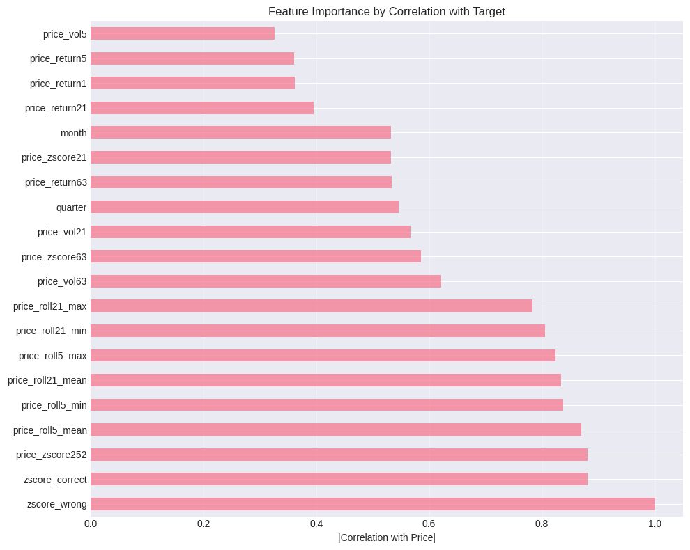

```python
# Calculate feature importance via correlation with target
target_corrs = corr_matrix['price'].drop('price').abs().sort_values(ascending=False)

print("\nTop 20 Features by Correlation with Price:")
print(target_corrs.head(20))

# Plot
fig, ax = plt.subplots(figsize=(10, 8))
target_corrs.head(20).plot(kind='barh', ax=ax, alpha=0.7)
ax.set_xlabel('|Correlation with Price|')
ax.set_title('Feature Importance by Correlation with Target')
ax.grid(True, alpha=0.3, axis='x')
plt.tight_layout()
plt.show()
```

## Part 9: Applying Features to Test Data

A critical test: Can we apply the same transformations to new (test) data?

**The engineer must use the same lookback windows and normalization parameters**.

```python
# Get test data
test_data = df.loc['2023-01-01':].copy()

print(f"Test data shape: {test_data.shape}")
print(f"Test date range: {test_data.index[0].date()} to {test_data.index[-1].date()}")

# Apply same feature engineering
test_features = create_commodity_features(
    test_data,
    price_column='price',
    inventory_column='inventory',
    production_column='production',
    consumption_column='consumption'
)

print(f"\nTest features shape: {test_features.shape}")
print(f"✓ Successfully applied feature engineering to test data")

# Verify feature alignment
train_cols = set(full_features.columns)
test_cols = set(test_features.columns)

missing_in_test = train_cols - test_cols
extra_in_test = test_cols - train_cols

if len(missing_in_test) > 0:
    print(f"\n⚠ Features missing in test: {missing_in_test}")
if len(extra_in_test) > 0:
    print(f"\n⚠ Extra features in test: {extra_in_test}")
if len(missing_in_test) == 0 and len(extra_in_test) == 0:
    print(f"\n✓ Train and test features perfectly aligned")
```

```
Test data shape: (365, 6)
Test date range: 2023-01-01 to 2023-12-31
```

```
Test features shape: (365, 42)
✓ Successfully applied feature engineering to test data

✓ Train and test features perfectly aligned
```

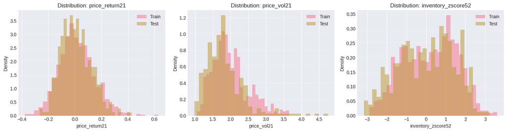

```
Distribution Statistics (Train vs Test):

price_return21:
  Train: μ=0.013, σ=0.136
  Test:  μ=0.008, σ=0.113

price_vol21:
  Train: μ=1.999, σ=0.506
  Test:  μ=1.822, σ=0.542

inventory_zscore52:
  Train: μ=0.191, σ=1.345
  Test:  μ=0.002, σ=1.416
```

```python
# Visualize feature distribution: train vs test
sample_features = ['price_return21', 'price_vol21', 'inventory_zscore52']
sample_features = [f for f in sample_features if f in full_features.columns and f in test_features.columns]

fig, axes = plt.subplots(1, len(sample_features), figsize=(15, 4))
if len(sample_features) == 1:
    axes = [axes]

for idx, feat in enumerate(sample_features):
    axes[idx].hist(full_features[feat].dropna(), bins=30, alpha=0.5, label='Train', density=True)
    axes[idx].hist(test_features[feat].dropna(), bins=30, alpha=0.5, label='Test', density=True)
    axes[idx].set_xlabel(feat)
    axes[idx].set_ylabel('Density')
    axes[idx].set_title(f'Distribution: {feat}')
    axes[idx].legend()
    axes[idx].grid(True, alpha=0.3, axis='y')

plt.tight_layout()
plt.show()

print("\nDistribution Statistics (Train vs Test):")
for feat in sample_features:
    train_mean = full_features[feat].mean()
    test_mean = test_features[feat].mean()
    train_std = full_features[feat].std()
    test_std = test_features[feat].std()
    print(f"\n{feat}:")
    print(f"  Train: μ={train_mean:.3f}, σ={train_std:.3f}")
    print(f"  Test:  μ={test_mean:.3f}, σ={test_std:.3f}")
```

## Part 10: Best Practices Summary

### ✓ Do's

1. **Always use rolling windows** for statistics (mean, std, etc.)
2. **Document feature lineage** with metadata
3. **Use consistent transformations** across train/test
4. **Handle missing values explicitly** (don't assume)
5. **Test on out-of-sample data** to verify no leakage
6. **Normalize lookback periods** (e.g., 21d ≈ 1 month)

### ✗ Don'ts

1. **Never use `.mean()` or `.std()` on entire dataset**
2. **Don't use future information** in feature calculation
3. **Don't assume data is clean** (always check)
4. **Don't create features that can't be computed in production**
5. **Don't ignore feature correlations** (multicollinearity matters)

### Critical Questions to Ask

Before adding any feature:

1. **Is this feature available in real-time?**
   - Can I compute it with only past data?
   - Will it have revisions?
2. **What's the economic intuition?**
   - Why should this predict prices?
   - Is there a fundamental relationship?
3. **How stable is this feature?**
   - Does it work across different time periods?
   - Is it regime-dependent?
4. **What's the feature's half-life?**
   - How quickly does information decay?
   - Should I use a shorter lookback?

### The Production Reality Check

**Before deploying, ask: Can my feature engineer run at 9:30 AM on Monday with only data available at that moment?**

If the answer is no, you have look-ahead bias.

## Exercises

1. **Create a "smart money" feature**: Use volume and open interest to identify when informed traders are active
2. **Build a regime detection feature**: Identify market regimes (trending vs mean-reverting) using rolling statistics
3. **Engineer a "stress index"**: Combine volatility, inventory levels, and supply-demand balance into a single stress measure
4. **Implement Fourier features**: Capture complex seasonal patterns using Fourier basis functions
5. **Create forward curve features**: If you have futures data, build features from the term structure slope and curvature

## Key Takeaways

1. **Temporal discipline is non-negotiable** - One instance of look-ahead bias can invalidate your entire backtest
2. **The `TemporalFeatureEngineer` automates temporal feature creation** while maintaining strict discipline
3. **Price-based features** (returns, volatility, z-scores) capture market dynamics
4. **Fundamental features** (inventory, supply-demand) encode economic theory
5. **Seasonal and interaction features** capture complex patterns and non-linearities
6. **Feature metadata tracking** is essential for documentation and production deployment
7. **Always test features on out-of-sample data** to verify they can be computed in real-time

## Next Steps

In **Module 7: Model Validation with Walk-Forward Testing**, we'll learn how to validate fair value models using proper time series cross-validation that respects temporal order and prevents data leakage.